# SRM Chapter 2.3

theBudgetActuary

# **KNN**

#### *Supervised/Unsupervised:* **Supervised**

#### *Type of Model:* **Regression and Classification**

#### *Parametric/Non-Parametric:* **Non-Parametric**

#### *Tuning Parameters:* **k - Number of Nearest Neighbors**

# **How Does it Work?**

## **KNN for Regression:**

KNN doesn’t build a model from the training set, but instead is a memory based approach. A prediction is made by finding the closest k observations and averaging the dependent variables results. (Hastie et al., 2017)

## **KNN for Classification:**

KNN for classification works the same way as for regression. The only difference is when it locates the closest k observations, it takes the mode instead of the mean. The most common metric to find the distance between observations is Euclidean Distance.

> Euclidean Distance: $d(x,y)= \sqrt{\sum_{i=1}^{n} (x_{i}-y_{i})^2}$

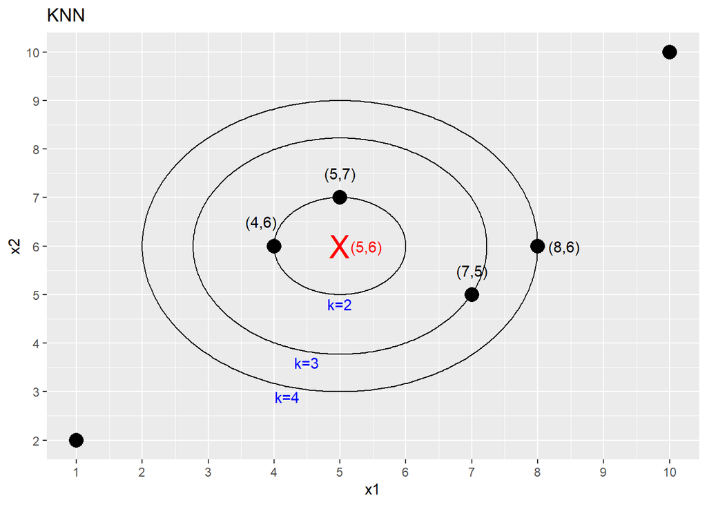

In the graph above the KNN algorithm is being used with 6 training observations represented by the black dots above. The three circles represent the nearest observations for an observation of (5,6) at k = 2, 3, and 4 nearest neighbors.

| x1 | x2 | y |
| --- | --- | --- |
| 1 | 2 | 7 |
| 4 | 6 | 3 |
| 5 | 7 | 6 |
| 7 | 5 | 8 |
| 8 | 6 | 7 |
| 10 | 10 | 7 |

The table above represents the training data used for the KNN algorithm. If k=3 for the observation of (5,6), the observations of (4,6), (5,7) and (7,5) y values would be averaged together to predict the value of the (5,6) y values. This would produce a $\frac{3+6+8}{3} = 5.66$ prediction value for y.

# **Tuning Parameter k**

Unlike SLR the KNN algorithm has a tuning parameter. Tuning parameters allow the user to control the flexibility of a statistical learning algorithm. The k parameter can take any value from 1 to n, with n being the number of observations.

Choosing a smaller k value results with a smaller bias. Bias is how close we can get our predictions to the actual values of the dependent variable. Choosing a larger k value results in a lower variance. Variance is the amount f(x) will change if we use a new training set. From chapter 1 we learned that the Test MSE = Squared Bias + Variance + Var($\epsilon$), so our goal is to pick a value of k to minimize this value.

Setting the tuning parameter to k = n, the KNN algorithm would guess the mean of the dependent variable for every observation in regression, or the mode of all observations for classification. On the extremes a value of k = 1 results in a train MSE of 0 or a train accuracy of 100%. It would guess every observation perfectly. This is why using the same data to train a model should not be used to judge the performance of a model. We will not learn to find the best value of k in terms of test MSE until the end of the next chapter.

# **Advantages/Disadvantages Compared to SLR**

## **Advantages**

With KNN being a non-parametric method it takes no functional form. This allows KNN to model highly irregular relationships which SLR would not be able to. SLR requires linear relationships in order to achieve accurate results.

KNN has a tuning parameter which gives the ability to control the complexity of the model and adjust the flexibility as needed.

## **Disadvantages**

KNN has no functional form meaning no parameters are estimated. This means the interpretability that SLR provides is lost. Also, with not having a functional form KNN generally needs more observations per predictor in order to produce accurate results. (James et al.)

##### **Sources:**

James, G., Witten, D., Hastie, T., & Tibshirani, R. (n.d.). An introduction to statistical learning: With applications in R.

Hastie, T., Friedman, J., & Tisbshirani, R. (2017). In The elements of Statistical Learning: Data Mining, Inference, and prediction (pp. 463). essay, Springer.